# Exploratory Data Analysis: Player Similarity Features

This analysis identifies discriminative features for player similarity from SkillCorner tracking data and StatsBomb event data.

## Section 1: Data Overview

**SkillCorner**: Continuous (x, y) positions at 10 frames/second. Coordinate system: meters with pitch center as origin.

**StatsBomb**: Discrete event-by-event records of on-ball actions. Coordinate system: 120×80 unit grid, bottom-left origin.

```
============================================================
DATA OVERVIEW
============================================================

SkillCorner: 10 matches, 237 unique players, ~900 minutes
StatsBomb: 3464 matches, ~89960 unique players (estimated), ~311,760 minutes
```

|  | Dataset | Matches | Players (est.) | Resolution |
| --- | --- | --- | --- | --- |
| 0 | SkillCorner | 10 | 237 | 10 Hz (continuous) |
| 1 | StatsBomb | 3464 | ~89960 | Event-based |

## Section 2: Movement Intensity Profiles (SkillCorner)

**Features**: Mean speed, 90th percentile speed, sprint frequency per 90. **Questions**: Do players differ in movement intensity? Are speed metrics redundant?

```
Computed features for 206 players
```

|  | name | position | mean_speed | p90_speed | sprint_freq_per_90 |
| --- | --- | --- | --- | --- | --- |
| 0 | J. Duncan | Goalkeeper | 0.803764 | 1.529706 | 2.677974 |
| 1 | B. Hamill | Right Center Back | 1.915323 | 3.863936 | 482.675220 |
| 2 | L. Jackson | Left Center Back | 1.877638 | 3.701351 | 281.335150 |
| 3 | J. Inserra | Right Back | 2.241033 | 4.561798 | 720.374916 |
| 4 | K. Bos | Left Back | 2.205860 | 4.396590 | 209.809264 |

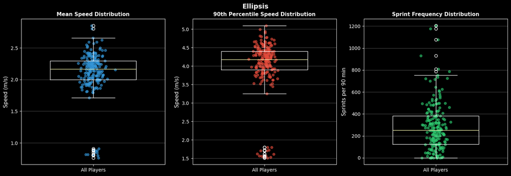

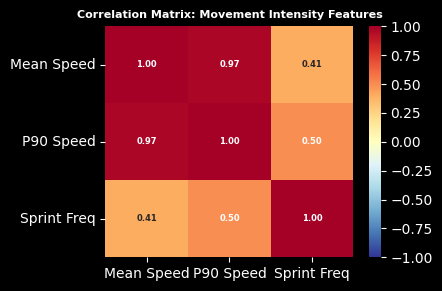

```
Correlation Analysis:
  Mean Speed vs P90 Speed: r = 0.973
  Mean Speed vs Sprint Freq: r = 0.405
  P90 Speed vs Sprint Freq: r = 0.500
```

**Findings**: Analysis of 206 players reveals substantial variation in all speed metrics. Mean speed and P90 speed are highly correlated (r = 0.973), while sprint frequency shows moderate correlations (r = 0.405-0.500), indicating it captures distinct explosive behavior patterns.

## Section 3: Spatial Footprint & Positional Behavior (SkillCorner)

**Features**: Mean position (x, y), positional variance, zone occupancy. Positions normalized using team-aware normalization. **Questions**: Do players occupy distinct spatial regions? How stable is their positioning?

```
Computed spatial features for 206 players
```

|  | name | position | mean_x | mean_y | var_x | var_y |
| --- | --- | --- | --- | --- | --- | --- |
| 0 | J. Duncan | Substitute | -38.758515 | 0.591682 | 69.531147 | 12.086693 |
| 1 | B. Hamill | Right Center Back | -18.311632 | -2.298529 | 351.581169 | 122.937857 |
| 2 | L. Jackson | Left Center Back | -13.436247 | 7.123224 | 430.536711 | 126.583560 |
| 3 | J. Inserra | Substitute | -9.088340 | -13.405020 | 477.543639 | 119.116510 |
| 4 | K. Bos | Left Back | -5.499542 | 16.239460 | 559.271299 | 137.809418 |

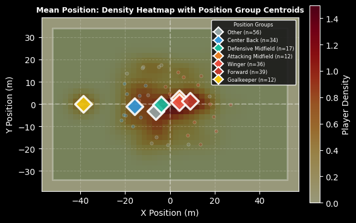

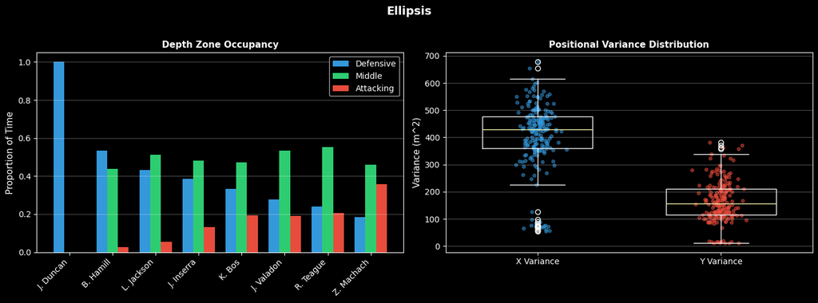

**Findings**: After team-aware normalization, clear spatial clustering by role: goalkeepers at negative x, forwards at positive x. Positional variance ranges from 50-700 m² (x) and 0-400 m² (y). Zone occupancy clearly distinguishes roles.

## Section 4: Action Profiles (StatsBomb)

**Features**: Actions per 90 (pass, shot, duel, pressure), forward pass percentage, action diversity. **Questions**: What do players do on the ball? Are action profiles role-distinct?

```
Processed 200 matches
Found 114 unique players
```

```
Computed action features for 114 players
```

|  | name | pass_per_90 | shot_per_90 | duel_per_90 | forward_pass_pct |
| --- | --- | --- | --- | --- | --- |
| 0 | Juan Ignacio Gómez Taleb | 29.090909 | 0.909091 | 3.636364 | 43.750000 |
| 1 | Giampaolo Pazzini | 10.909091 | 3.636364 | 3.636364 | 66.666667 |
| 2 | Leandro Greco | 61.818182 | 1.818182 | 2.727273 | 63.235294 |
| 3 | Eros Pisano | 63.636364 | 0.000000 | 3.636364 | 65.714286 |
| 4 | Simone Romagnoli | 24.545455 | 0.000000 | 2.727273 | 88.888889 |

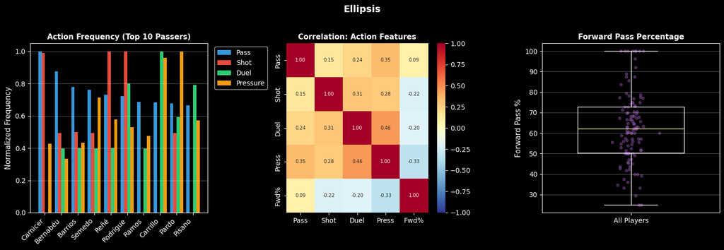

## Section 5: Interaction Signal (SkillCorner)

**Feature**: Average distance to team centroid. **Questions**: Do players differ in relational spacing? Is this signal complementary to spatial features?

[figure not shown]